# data_tidying

## Data tidying

```
"Tidy datasets are all alike, but every messy dataset is messy in its own way." –– Hadley Wickham
```

El "data tidying" o limpieza de datos es un proceso fundamental en el ámbito de data science y data analytics. El propósito principal es preparar y organizar los datos de manera que sean adecuados para el análisis. Algunos de los objetivos específicos del data tidying incluyen:

1. **Facilitar el Análisis:** Datos bien organizados facilitan la exploración y análisis, permitiendo a los científicos de datos centrarse en la interpretación y obtención de información valiosa.
2. **Eliminar Inconsistencias:** Durante el proceso de recolección de datos, es común encontrar valores faltantes, errores tipográficos, o datos inconsistentes. La limpieza de datos busca corregir estos problemas para evitar interpretaciones erróneas.
3. **Consolidar Datos:** A veces, los datos pueden estar distribuidos en diferentes fuentes o formatos. La limpieza implica consolidar la información de manera coherente para que sea más fácil de analizar.
4. **Manejar Datos Faltantes:** Identificar y tratar adecuadamente los valores faltantes es crucial. Esto puede implicar la imputación de valores, la eliminación de observaciones o el diseño de estrategias específicas según el caso.
5. **Normalizar Formatos:** Asegurarse de que los datos estén en el formato correcto y que las unidades sean coherentes para que los resultados del análisis sean significativos.
6. **Crear Conjuntos de Datos Consistentes:** Los datos tidied se presentan en estructuras coherentes y fáciles de entender, lo que facilita su utilización por parte de otros profesionales o sistemas.
7. **Mejorar la Reproducibilidad:** La limpieza de datos bien documentada y reproducible es esencial para que otros científicos de datos o investigadores puedan comprender y replicar los análisis.

### Características de datos tydy

Los datos ordenados, también conocidos como datos "tidy" en el contexto de la limpieza y organización de datos, poseen ciertas características clave. Estas características facilitan el análisis y la interpretación de los datos. Las principales características de los datos ordenados son:

1. **Cada variable tiene su propia columna:** Cada característica o variable está representada en una columna separada. Esto facilita la identificación y extracción de información específica.
2. **Cada observación tiene su propia fila:** Cada instancia u observación individual se registra en una fila única. Esto ayuda a mantener la coherencia y facilita la comparación entre diferentes observaciones.
3. **Cada valor ocupa su propia celda:** Cada entrada en la tabla de datos se encuentra en su propia celda única. Esto asegura la organización y facilita el acceso a datos específicos.
4. **La tabla tiene una estructura rectangular:** Los datos están organizados en una estructura de tabla rectangular, donde todas las filas tienen el mismo conjunto de columnas. Esto simplifica el proceso de análisis y manipulación.
5. **La primera fila contiene encabezados:** La primera fila de la tabla generalmente contiene nombres de variables o encabezados, lo que proporciona información sobre el contenido de cada columna.

La figura siguiente muestra esquemáticamente las características listadas:

[figure not shown]

Imagen tomada de: https://r4ds.had.co.nz/tidy-data.html

6. **La tabla debe ser fácil de entender:** Los datos ordenados son presentados de manera clara y comprensible, lo que facilita su interpretación por parte de los usuarios y su uso en análisis estadísticos.
7. **Debe permitir operaciones eficientes:** La organización adecuada de los datos facilita la realización de operaciones como filtrado, agrupación, y análisis estadísticos, lo que contribuye a un flujo de trabajo más eficiente.

Estas características son fundamentales para garantizar que los datos sean manejables y comprensibles, lo que a su vez facilita la toma de decisiones informadas y la generación de conocimiento a partir de los datos.

## Operaciones comunes que se usan en data tydying

### Pivoteo en Data Tidying

El pivoteo es un proceso clave en la limpieza y organización de datos. Consiste en transformar un conjunto de datos para que sea más adecuado para el análisis, reorganizando las columnas y filas.

**Pivoteo Wide to Long:**

El pivoteo de "wide to long" es un proceso de reorganización de datos que transforma un conjunto de datos desde un formato ancho a un formato largo.

**Características del Formato Ancho (Wide):**

- Cada variable tiene su propia columna.
- Puede haber múltiples columnas que representan mediciones o condiciones en diferentes momentos.

**Pasos Comunes en el Pivoteo Wide to Long:**

1. **Identificar Variables Clave:** Seleccionar las variables que representan mediciones o condiciones en diferentes momentos.
2. **Derretir (Melt):** Combina estas variables en una sola columna y crea una columna adicional para almacenar los valores correspondientes.
3. **Crear una Columna de Tiempo o Condición:** Introducir una nueva variable que indique el momento o la condición asociada con cada valor.

**Ejemplo:**

Antes del pivoteo (wide):

| ID | T1_Score | T2_Score | T3_Score |
| --- | --- | --- | --- |
| 1 | 80 | 85 | 90 |
| 2 | 75 | 78 | 80 |

Después del pivoteo (long):

| ID | Time | Score |
| --- | --- | --- |
| 1 | T1 | 80 |
| 1 | T2 | 85 |
| 1 | T3 | 90 |
| 2 | T1 | 75 |
| 2 | T2 | 78 |
| 2 | T3 | 80 |

En este ejemplo, hemos pivoteado los datos desde un formato ancho a uno largo, lo que facilita el análisis de las puntuaciones a lo largo del tiempo para cada individuo.

La figura siguiente muestra esquemáticamente el pivoteo wide to long:

[figure not shown]

Imagen tomada de: https://r4ds.had.co.nz/tidy-data.html

**Pivoteo Long to Wide:**

El pivoteo de "long to wide" es un proceso de reorganización de datos que transforma un conjunto de datos desde un formato largo a un formato ancho.

**Características del Formato Largo (Long):**

- Cada observación tiene su propia fila.
- Puede haber múltiples filas para la misma entidad, cada una representando una observación diferente.

**Pasos Comunes en el Pivoteo Long to Wide:**

1. **Identificar Variables Clave:** Seleccionar las variables que serán las nuevas columnas en el formato ancho.
2. **Pivotear:** Organizar los datos de manera que las observaciones únicas para cada entidad se conviertan en filas y las variables seleccionadas se conviertan en nuevas columnas.
3. **Lidiar con Valores Múltiples:** Decidir cómo manejar situaciones en las que hay múltiples observaciones para la misma entidad y variable (por ejemplo, agregación, toma del primer/último valor, etc.).

**Ejemplo:**

Antes del pivoteo (long):

| ID | Variable | Value |
| --- | --- | --- |
| 1 | A | 10 |
| 1 | B | 15 |
| 2 | A | 20 |
| 2 | B | 25 |

Después del pivoteo (wide):

| ID | A | B |
| --- | --- | --- |
| 1 | 10 | 15 |
| 2 | 20 | 25 |

En este ejemplo, hemos pivoteado los datos desde un formato largo a uno ancho, lo que facilita el análisis de las diferentes variables para cada entidad.

La figura siguiente muestra esquemáticamente el pivoteo long to wide:

[figure not shown]

Imagen tomada de: https://r4ds.had.co.nz/tidy-data.html

### Separating y Uniting en Data Tidying

**Separating:**

La operación de "separating" implica dividir una columna que contiene información combinada en dos o más columnas separadas. Esto es útil cuando una columna contiene valores que en realidad representan múltiples variables o categorías.

**Ejemplo:** Antes de separar:

| ID | Name_Age |
| --- | --- |
| 1 | John_25 |
| 2 | Alice_30 |

Después de separar:

| ID | Name | Age |
| --- | --- | --- |
| 1 | John | 25 |
| 2 | Alice | 30 |

La figura siguiente muestra esquemáticamente la separación:

[figure not shown]

Imagen tomada de: https://r4ds.had.co.nz/tidy-data.html

**Uniting:**

La operación de "uniting" es lo opuesto a "separating". Se utiliza para combinar dos o más columnas en una sola columna. Esto es útil cuando queremos unir información de varias variables en una sola columna.

**Ejemplo:** Antes de unir:

| ID | Name | Age |
| --- | --- | --- |
| 1 | John | 25 |
| 2 | Alice | 30 |

Después de unir:

| ID | Name_Age |
| --- | --- |
| 1 | John_25 |
| 2 | Alice_30 |

Estas operaciones son esenciales para asegurar que los datos estén organizados de manera adecuada y sean más accesibles para análisis posteriores.

La figura siguiente muestra esquemáticamente la unión:

[figure not shown]

Imagen tomada de: https://r4ds.had.co.nz/tidy-data.html

### Preprocesamiento de Datos

El preprocesamiento de datos es un paso crucial en el análisis de datos y en el flujo de trabajo de aprendizaje automático. Involucra la limpieza y transformación de datos brutos en un formato adecuado para el análisis o para entrenar modelos de aprendizaje automático. El objetivo del preprocesamiento de datos es mejorar la calidad de los datos, aumentar su precisión y facilitar mejores resultados en pasos subsiguientes.

Tareas comunes en el preprocesamiento de datos incluyen:

1. **Manejo de Datos Faltantes:** Tratar los valores faltantes ya sea eliminándolos, imputándolos con valores estimados, o utilizando técnicas más avanzadas de imputación.
2. **Manejo de Valores Atípicos:** Identificar y manejar valores atípicos, que son puntos de datos que difieren significativamente del resto del conjunto de datos.
3. **Transformación de Datos:** Aplicar transformaciones a variables, como transformaciones logarítmicas o normalización, para hacer los datos más adecuados para el modelado.
4. **Codificación de Variables Categóricas:** Convertir variables categóricas a un formato numérico que pueda ser utilizado por algoritmos de aprendizaje automático. Esto puede incluir codificación one-hot, codificación de etiquetas u otros métodos.
5. **Escala y Estandarización:** Escalar características numéricas para asegurar que estén en una escala similar. Esto es especialmente importante para algoritmos sensibles a la magnitud de las características de entrada.
6. **Ingeniería de Características:** Crear nuevas características o modificar existentes para capturar información más relevante para el modelado.
7. **División de Datos:** Dividir el conjunto de datos en conjuntos de entrenamiento y prueba para evaluar modelos.

### Valores faltantes y cómo tratarlos

Los valores faltantes, también conocidos como valores nulos o valores perdidos, son aquellos que no están presentes en una variable o columna de datos en ciertas observaciones. Estos valores pueden surgir por diversas razones, como errores en la recopilación de datos, omisiones intencionales, o simplemente porque la información no está disponible.

**Tratamiento de Valores Faltantes:**

1. **Identificación de Valores Faltantes:**
   - Antes de abordar los valores faltantes, es importante identificar dónde se encuentran en el conjunto de datos. Puedes utilizar funciones o métodos específicos en tu plataforma de análisis de datos para detectarlos.
2. **Eliminación de Filas o Columnas:**
   - Si la cantidad de valores faltantes es pequeña en comparación con el tamaño total del conjunto de datos y no afecta significativamente el análisis, puedes optar por eliminar las filas o columnas que contienen valores faltantes.
3. **Imputación:**
   - La imputación implica estimar o predecir los valores faltantes utilizando información disponible. Puedes utilizar estadísticas descriptivas como la media, la mediana o la moda para llenar los valores faltantes. Otra opción es utilizar métodos más avanzados, como la imputación basada en modelos.
4. **Creación de Indicadores:**
   - En lugar de imputar valores faltantes, puedes agregar una columna adicional que actúe como indicador de la presencia de valores faltantes en la variable original. Esto permite conservar la información sobre la falta de datos.
5. **Manejo Contextual:**
   - En algunos casos, es posible que el valor faltante no sea simplemente una ausencia de datos, sino que tenga un significado específico. Por ejemplo, un campo de "Fecha de Finalización" no estaría lleno si la tarea aún no se ha completado. En estos casos, se puede optar por no tratar el valor faltante como un error, sino como una característica del conjunto de datos.
6. **Uso de Métodos Avanzados:**
   - En situaciones más complejas, especialmente en conjuntos de datos grandes y complejos, se pueden utilizar métodos más avanzados como la imputación múltiple o modelos de machine learning para tratar valores faltantes de manera más precisa.

La elección de la estrategia dependerá del contexto específico del conjunto de datos y del análisis que estás llevando a cabo. Es importante documentar y comunicar cómo se manejan los valores faltantes en tu análisis para garantizar la transparencia y la reproducibilidad.

**Técnicas de Imputación:**

Existen varias técnicas de imputación para tratar valores faltantes en conjuntos de datos. La elección de la técnica depende del tipo de datos y del contexto específico del problema. Aquí hay algunas técnicas comunes de imputación:

1. **Imputación por Media, Mediana o Moda:**
   - Esta técnica implica reemplazar los valores faltantes con la media, mediana o moda de la variable correspondiente. Es simple y adecuada para datos numéricos. Sin embargo, no tiene en cuenta la variabilidad entre las observaciones.
2. **Imputación por Vecinos más Cercanos (K-NN):**
   - Utiliza los valores de las observaciones más cercanas en términos de similitud para imputar los valores faltantes. Es eficaz tanto para variables numéricas como categóricas. Sin embargo, puede ser computacionalmente costoso y puede no funcionar bien en conjuntos de datos grandes o dispersos.
3. **Regresión Lineal o Múltiple:**
   - Se utiliza la regresión para predecir los valores faltantes en función de otras variables. Es efectiva cuando hay relaciones lineales en los datos, pero puede no funcionar bien si la relación no es lineal.
4. **Métodos de Imputación Múltiple (Multiple Imputation):**
   - Se generan varias imputaciones para los valores faltantes, y se realiza el análisis en cada conjunto imputado. Los resultados se combinan para obtener estimaciones más precisas. Es útil para manejar la incertidumbre asociada con los valores faltantes.
5. **Imputación Basada en Modelos (Model-based Imputation):**
   - Se utilizan modelos estadísticos o de machine learning para predecir los valores faltantes. Puede ser más preciso que la imputación por media o regresión, pero también puede ser más complejo y requerir más recursos computacionales.
6. **Imputación por Múltiples Métodos (MICE):**
   - Combina varias técnicas de imputación en un solo marco. En cada iteración, se imputan los valores faltantes utilizando un método específico, y este proceso se repite varias veces. Es flexible y puede adaptarse a la naturaleza de los datos.
7. **Imputación con Variables Dummy (Dummy Variable Imputation):**
   - Se crea una variable dummy que indica la presencia o ausencia de un valor faltante en la observación. Luego, se utiliza esta variable dummy junto con otras variables para imputar los valores faltantes.
8. **Imputación Hot-Deck:**
   - Consiste en emparejar observaciones con valores faltantes con observaciones similares que tengan valores conocidos. La información de las observaciones emparejadas se utiliza para imputar los valores faltantes.

**Técnicas de Imputación en Series Temporales:**

1. **Imputación Forward (Hacia Adelante):**
   - En la imputación forward, los valores faltantes se imputan utilizando información de observaciones previas en el tiempo. Es especialmente útil en series temporales donde la observación actual puede depender de valores pasados.

   *Ejemplo:*

[output not shown]

[output not shown]

En este caso, el valor faltante en T2 podría imputarse utilizando el valor en T1, ya que la serie temporal indica una cierta tendencia.

2. **Imputación Backward (Hacia Atrás):**
- En la imputación backward, los valores faltantes se imputan utilizando información de observaciones posteriores en el tiempo. Esta técnica puede ser útil si la observación actual se ve afectada por eventos futuros.

  *Ejemplo:*

| Tiempo | Valor |
| --- | --- |
| T1 | 10 |
| T2 | NaN |
| T3 | 25 |

[output not shown]

En este caso, el valor faltante en T2 podría imputarse utilizando el valor en T3, ya que la serie temporal indica una cierta tendencia futura.

3. **Imputación Lineal:**
- Esta técnica utiliza la interpolación lineal para imputar los valores faltantes en una serie temporal. Se calcula una línea recta entre las observaciones adyacentes y se estima el valor faltante en función de esta línea.
4. **Media Móvil:**
- Se utiliza la media de las observaciones vecinas para imputar los valores faltantes. La ventana de la media móvil puede ser fija o variable, dependiendo de la naturaleza de la serie temporal.
5. **Imputación de Vecinos más Cercanos Temporales (Time-based k-NN):**
- Similar al enfoque de vecinos más cercanos en datos estáticos, esta técnica encuentra observaciones similares en términos temporales y utiliza sus valores para imputar los valores faltantes.
6. **Spline Interpolation:**
- Se ajusta una curva spline a la serie temporal para imputar los valores faltantes. Las splines son funciones suaves que se adaptan bien a patrones complejos en los datos temporales.
7. **Imputación Basada en Modelos (Model-based Imputation):**
- Utiliza modelos estadísticos o de machine learning para predecir y imputar los valores faltantes. Pueden ser modelos autoregresivos, modelos ARIMA u otros modelos más complejos.
8. **Imputación Estacional:**
- Considera patrones estacionales en la serie temporal y utiliza información estacional para imputar los valores faltantes.
9. **Imputación Múltiple:**
- Similar a la imputación múltiple en datos estáticos, se generan múltiples series temporales imputadas y se realizan análisis posteriores considerando la variabilidad entre las imputaciones.
10. **Métodos de Suavizado (Smoothing Methods):**
- Emplea técnicas de suavizado, como el suavizado exponencial, para imputar valores faltantes. Estos métodos son especialmente útiles cuando hay patrones de tendencia y estacionalidad en la serie temporal.

La elección de la técnica de imputación depende de varios factores, como la naturaleza de los datos, la cantidad de valores faltantes y la complejidad del problema. Es recomendable evaluar el rendimiento de diferentes métodos en el contexto específico antes de seleccionar la técnica de imputación más adecuada.

### Discretización de Datos

La discretización de datos es el proceso de transformar variables continuas en variables discretas. Esto implica dividir el rango de valores de una variable continua en intervalos o categorías discretas. Aquí hay algunas técnicas comunes de discretización:

1. **Binning (Bandeo):**
   - Consiste en dividir el rango de valores en intervalos (bins) y asignar cada valor a uno de estos intervalos. Puede ser equidistante o basado en cuantiles.
2. **Equal-Width Binning (Bandeo de Ancho Equitativo):**
   - Divide el rango de valores en intervalos de ancho fijo. Por ejemplo, si tienes valores entre 0 y 100 y decides tener 5 bins, cada bin tendría un ancho de 20 unidades.
3. **Equal-Frequency Binning (Bandeo de Frecuencia Equitativa):**
   - Asigna aproximadamente el mismo número de observaciones a cada bin. Esto puede resultar en intervalos de ancho variable.
4. **K-Means Clustering:**
   - Utiliza el algoritmo de clustering K-Means para agrupar valores similares en k clusters y luego asigna cada valor al cluster correspondiente.
5. **Decision Trees:**
   - Puedes utilizar un árbol de decisión para identificar puntos de corte óptimos y discretizar la variable basándote en las divisiones del árbol.
6. **Custom Binning:**
   - Permite la creación de intervalos personalizados según el conocimiento del dominio o requisitos específicos del problema.

**Ejemplo:** Supongamos que tenemos una variable continua "Edad" con valores entre 20 y 60, y queremos discretizarla en tres grupos: "Joven", "Adulto" y "Mayor". Podríamos aplicar una discretización personalizada para asignar valores a cada grupo según rangos específicos.

| Edad | Grupo |
| --- | --- |
| 25 | Joven |
| 40 | Adulto |
| 55 | Mayor |
| ... | ... |

La elección de la técnica de discretización dependerá del contexto del problema y de los requisitos específicos del análisis o modelo.

**Discretización Ad Hoc Bajo Criterio de Experto**

La discretización ad hoc bajo criterio de experto es un enfoque en el cual se realiza la transformación de variables continuas en categorías discretas según el juicio y el conocimiento experto en el dominio específico. A diferencia de métodos automatizados, como binning equitativo o clustering, esta técnica depende completamente de la experiencia y la intuición de un experto en el campo.

**Proceso:**

1. **Evaluación del Contexto:**
   - El experto revisa el contexto del problema y comprende la naturaleza de la variable que se va a discretizar.
2. **Identificación de Puntos de Corte:**
   - El experto decide dónde establecer los puntos de corte para definir las categorías discretas. Esto puede basarse en conocimientos sobre el significado práctico de los valores, patrones observados o cualquier otro criterio relevante.
3. **Definición de Categorías:**
   - Se definen las categorías discretas y se asignan los valores a cada categoría según los puntos de corte establecidos. Esto puede implicar la creación de categorías específicas con significados relevantes en el dominio.

**Ejemplo:** Supongamos que tenemos una variable de ingresos mensuales y queremos discretizarla. Un experto en economía podría decidir que las categorías serán "Bajo", "Medio" y "Alto" según sus conocimientos sobre los estándares económicos y las condiciones locales.

| Ingresos | Categoría |
| --- | --- |
| 800 | Bajo |
| 2000 | Medio |
| 5000 | Alto |
| ... | ... |

Este enfoque ad hoc es particularmente útil cuando la discretización no puede ser fácilmente definida por reglas automáticas y requiere un entendimiento profundo del dominio.

La discretización ad hoc bajo criterio de experto proporciona flexibilidad y permite adaptarse a situaciones específicas que pueden no ser capturadas por métodos automáticos.

### Escalado

La escala es un aspecto específico del preprocesamiento de datos que se centra en transformar características numéricas a una escala estándar. El objetivo es asegurar que ninguna característica en particular domine a las demás debido a diferencias en sus magnitudes. La escala es especialmente importante para algoritmos que dependen de medidas de distancia, optimización mediante descenso de gradiente o cualquier método sensible a la escala de las características de entrada.

Técnicas comunes de escala incluyen:

1. **Escala Min-Max (Normalización):** Escalar características a un rango específico, a menudo entre 0 y 1.
2. **Estandarización (Normalización Z-score):** Escalar características para que tengan una media de 0 y una desviación estándar de 1.
3. **Escala Robusta:** Escalar características basadas en percentiles, siendo menos sensible a valores atípicos.

La elección del método de escala adecuado depende de las características de los datos y de los requisitos del algoritmo de aprendizaje automático que se esté utilizando. En general, el preprocesamiento de datos, incluida la escala, es un paso crucial para preparar los datos para el análisis y el entrenamiento de modelos, asegurando que los datos estén en un formato adecuado para obtener resultados precisos y significativos.

### Fuentes y recursos

- Wickham, H., Çetinkaya-Rundel, M., & Grolemund, G. (2023). [R for data science](https://r4ds.had.co.nz/tidy-data.html). O'Reilly Media, Inc.
- [Preprocesamiento de datos](https://view.genial.ly/63ebe6a082b0f90019529acd)

## Ejemplo práctico: Preparación de un Conjunto de Datos para Modelos Predictivos de Calidad del Aire

El conjunto de datos que se analizará proviene de la Secretaría de Ambiente de la Municipalidad de Quito, Ecuador. Se incluyeron diversas variables meteorológicas y de química atmosférica en el análisis.

A continuación, se detallan las variables utilizadas en este ejercicio:

### Objetivo

El objetivo es realizar una preparación exhaustiva del conjunto de datos con el fin de construir modelos predictivos que evalúen la calidad del aire. Esto implica considerar diversas etapas esenciales, como la limpieza de datos (Data Tidying), la unión de conjuntos de datos relevantes, la discretización de variables, la gestión de valores faltantes y la visualización de información clave.

1. **Limpieza de Datos (Data Tidying):** Se llevará a cabo un proceso integral para asegurar que los datos estén estructurados de manera coherente y libre de inconsistencias. Esto incluye la normalización de nombres de variables, la corrección de errores tipográficos y la estandarización de formatos para facilitar su análisis.
2. **Unión de Datos:** La integración de conjuntos de datos relevantes provenientes de diferentes fuentes será cuidadosamente realizada. Esto garantizará que se cuente con información completa de las variables mencionadas para mejorar la capacidad predictiva de los modelos.
3. **Discretización:** Se implementará un proceso de discretización para transformar variables continuas en categorías, facilitando así la interpretación y aplicación de modelos predictivos. La elección de los intervalos y la metodología de discretización se realizará de acuerdo al criterio de expertos.
4. **Gestión de Valores Faltantes:** Se aplicarán técnicas avanzadas para abordar valores faltantes, como la imputación basada en modelos o la eliminación cuidadosa de observaciones incompletas. El objetivo es preservar la integridad de los datos sin introducir sesgos significativos.
5. **Visualización:** La creación de visualizaciones claras y significativas será una parte fundamental del proceso. Esto incluirá gráficos descriptivos, mapas de calor y otras representaciones visuales que ayudarán a comprender patrones en los datos y respaldarán la toma de decisiones informada.
6. **Feature Engineering:** Se llevará a cabo la ingeniería de características para crear nuevas variables que puedan mejorar la capacidad predictiva de los modelos. Esto incluye la combinación de variables existentes o transformaciones que revelen información adicional sobre la calidad del aire.

Este enfoque meticuloso en cada etapa del proceso de preparación de datos establece una base sólida para la construcción de modelos predictivos de calidad del aire, garantizando la fiabilidad y robustez de los resultados obtenidos.

### Paquetes

```
!pip install xlrd
!pip install missingno
```

### Datos

Los datos para este ejemplo se encuentran disponibles en archivos Excel (xls) y pueden descargarse desde el siguiente enlace: [Datos Horarios Históricos](http://www.quitoambiente.gob.ec/ambiente/index.php/datos-horarios-historicos).

1. Descarga el archivo zip que contiene los datos [aquí](https://drive.google.com/open?id=0B-dmEvN59Z2ZYWhJWXhvMExFRjQ).
2. Descomprime el archivo y explora su contenido.
3. Observa los nombres de las columnas en los archivos Excel. Asegúrate de que no haya espacios ni caracteres especiales en los nombres de las columnas, ya que esto puede afectar el análisis y modelado posterior.
- Para una visualización preliminar del contenido de un archivo, ábrelo en tu computadora y revisa su estructura.
- Cada variable (Wind speed, Wind direction, Precipitation, PM2.5) se encuentra en un archivo individual.
  - Queremos procesar cada archivo y unirlos para tener un dataframe final con la siguiente estructura:

|  | DATE | PRECIPITATION(mm) | WINDDIR(deg) | WINDSPEED(m/s) | PARTICULAS(microg/m3) |
| --- | --- | --- | --- | --- | --- |
| 0 | 01/06/2007 | 9.3 | 125.09 | 1.91 | 24.84 |
| 1 | 04/06/2007 | 0.1 | 200.03 | 2.77 | 17.81 |
| 2 | 05/06/2007 | 0 | 178.09 | 3.24 | 15.86 |

- Piense cuales operaciones requiere para unir los archivos individuales en excel y obtener este resultado.

El método replace en un DataFrame de pandas para reemplazar los valores vacíos o compuestos únicamente por espacios en blanco en la columna "pm25" con el valor np.nan (representación estándar de valores faltantes en pandas). Aquí está la explicación detallada:

El método `replace` de pandas se usa para modificar un DataFrame.

```
pm25.replace(r'^\s*$', np.nan, regex=True, inplace=True)
```

- `pm25`: Se refiere a un DataFrame o a una serie en pandas, donde se desea realizar el reemplazo en la columna "pm25".
- `replace`: Es un método de pandas que se utiliza para realizar reemplazos en un DataFrame o en una Serie.
- `r'^\s*$'`: Es una expresión regular (regex) que busca patrones en los datos. En este caso:
- `^`: Indica el comienzo de la cadena.
- `\s*`: Representa cero o más espacios en blanco.
- `$`: Indica el final de la cadena. En conjunto, esta expresión regular busca cadenas que consistan únicamente de espacios en blanco (o estén completamente vacías).
- `np.nan`: Es el valor que se utilizará para reemplazar las coincidencias encontradas por la expresión regular. En este caso, se está utilizando np.nan, que es la convención en pandas para representar valores faltantes.
- `regex=True`: Indica que la expresión proporcionada es una expresión regular.
- `inplace=True`: Significa que el reemplazo se realizará directamente en el DataFrame original, en lugar de devolver un nuevo DataFrame con los cambios.

```python
import pandas as pd  # importamos módulo pandas
import numpy as np  # módulo numpy
import matplotlib.pyplot as plt  # librería base para graficar

pm25 = pd.read_excel('./data/aq_quito/03pm25ugm3.xls')  # Leemos archivo excel

# Espacios en blanco han sido leídos como strings
# reemplazamos celdas que contenga espacios en blanco
# por nan
# ^ caracter al inicio
# $ caracter al final
# \s cualquier espacio en blanco
# r'' raw string
pm25.replace(r'^\s*$', np.nan, regex=True, inplace = True)

pm25.head(3)  # Primeros 3 registros
```

|  | ESTACION | MAGNITUD | ANO | MES | DIA | HORA1 | HORA2 | HORA3 | HORA4 | HORA5 | ... | HORA15 | HORA16 | HORA17 | HORA18 | HORA19 | HORA20 | HORA21 | HORA22 | HORA23 | HORA24 |
| --- | --- | --- | --- | --- | --- | --- | --- | --- | --- | --- | --- | --- | --- | --- | --- | --- | --- | --- | --- | --- | --- |
| 0 | COTOCOLLAO | PM2.5 | 2008 | 1 | 1 | 82.94 | 165.31 | 59.23 | 43.73 | 35.25 | ... | 1.83 | 5.84 | 1.85 | 5.74 | 8.10 | 13.68 | 1.93 | 1.30 | 1.58 | 5.87 |
| 1 | COTOCOLLAO | PM2.5 | 2008 | 1 | 2 | 1.52 | 2.76 | 2.70 | 2.44 | 8.88 | ... | 1.23 | 6.33 | 2.31 | 3.83 | 2.52 | 6.63 | 13.84 | 7.40 | 2.42 | 2.68 |
| 2 | COTOCOLLAO | PM2.5 | 2008 | 1 | 3 | 0.41 | 8.54 | 3.57 | 1.37 | 3.82 | ... | 5.86 | 1.71 | 1.06 | 5.74 | 8.24 | 7.44 | 16.27 | 16.36 | 6.33 | 8.57 |

3 rows × 29 columns

- Observe la estructura del `dataframe`
- Tiene un formato wide, para nuestro análisis.
- Vamos a procesar cada archivo de excel y unir el resultado en un solo dataframe, para cada estación.
- El resultado final debería ser:

|  | DATE | PRECIPITATION(mm) | WINDDIR(deg) | WINDSPEED(m/s) | PARTICULAS(microg/m3) |
| --- | --- | --- | --- | --- | --- |
| 0 | 01/06/2007 | 9.3 | 125.09 | 1.91 | 24.84 |
| 1 | 04/06/2007 | 0.1 | 200.03 | 2.77 | 17.81 |
| 2 | 05/06/2007 | 0 | 178.09 | 3.24 | 15.86 |

```python
pm25.ESTACION.unique()  # Elementos únicos en ESTACION
```

```
array(['COTOCOLLAO', 'CARAPUNGO', 'BELISARIO', 'EL CAMAL', 'CENTRO',
       'GUAMANI', 'LOS CHILLOS'], dtype=object)
```

```python
pm25.describe()  # describe el dataset
```

|  | ANO | MES | DIA | HORA1 | HORA2 | HORA3 | HORA4 | HORA5 | HORA6 | HORA7 | ... | HORA15 | HORA16 | HORA17 | HORA18 | HORA19 | HORA20 | HORA21 | HORA22 | HORA23 | HORA24 |
| --- | --- | --- | --- | --- | --- | --- | --- | --- | --- | --- | --- | --- | --- | --- | --- | --- | --- | --- | --- | --- | --- |
| count | 15877.000000 | 15877.000000 | 15877.000000 | 15236.000000 | 15735.000000 | 15738.000000 | 15736.000000 | 15740.000000 | 15736.000000 | 15732.000000 | ... | 15361.00000 | 15452.000000 | 15554.000000 | 15657.000000 | 15686.000000 | 15702.000000 | 15670.000000 | 15677.000000 | 15534.000000 | 13542.000000 |
| mean | 2011.871827 | 6.347862 | 15.697235 | 18.045639 | 17.522143 | 15.666597 | 15.036322 | 15.175451 | 16.764140 | 24.747702 | ... | 14.90512 | 15.173436 | 15.345607 | 16.633985 | 17.877312 | 17.964799 | 18.387192 | 17.908218 | 16.677536 | 15.904846 |
| std | 2.503338 | 3.408190 | 8.804852 | 13.770792 | 18.217193 | 14.053011 | 12.360683 | 11.286948 | 10.868982 | 15.628660 | ... | 10.70912 | 10.171950 | 9.554409 | 9.701766 | 9.258291 | 9.326566 | 9.520316 | 9.747207 | 9.599400 | 9.942222 |
| min | 2008.000000 | 1.000000 | 1.000000 | 0.000000 | 0.000000 | 0.000000 | 0.000000 | 0.000000 | 0.000000 | 0.000000 | ... | 0.00000 | 0.000000 | 0.000000 | 0.000000 | 0.000000 | 0.000000 | 0.000000 | 0.000000 | 0.000000 | 0.000000 |
| 25% | 2010.000000 | 3.000000 | 8.000000 | 9.320000 | 9.760000 | 8.280000 | 7.940000 | 8.070000 | 9.480000 | 14.340000 | ... | 8.09000 | 8.530000 | 9.110000 | 10.540000 | 11.692500 | 11.460000 | 11.850000 | 11.120000 | 9.950000 | 8.970000 |
| 50% | 2012.000000 | 6.000000 | 16.000000 | 16.425000 | 15.490000 | 13.920000 | 13.265000 | 13.640000 | 15.390000 | 22.060000 | ... | 13.19000 | 13.650000 | 13.945000 | 15.400000 | 16.940000 | 16.890000 | 17.170000 | 16.520000 | 15.190000 | 14.210000 |
| 75% | 2014.000000 | 9.000000 | 23.000000 | 24.202500 | 22.160000 | 20.590000 | 19.800000 | 20.210000 | 22.030000 | 31.600000 | ... | 19.74000 | 19.880000 | 19.880000 | 21.270000 | 22.697500 | 23.020000 | 23.420000 | 22.880000 | 21.550000 | 20.827500 |
| max | 2016.000000 | 12.000000 | 31.000000 | 353.860000 | 648.380000 | 462.470000 | 416.260000 | 404.380000 | 342.540000 | 328.930000 | ... | 329.47000 | 245.780000 | 177.600000 | 325.700000 | 161.870000 | 145.080000 | 142.810000 | 139.480000 | 141.500000 | 105.200000 |

8 rows × 27 columns

**isnull**

En pandas, el método para verificar si un valor es nulo es **`isnull()`**. Este método devuelve un DataFrame o una Serie de valores booleanos que indican si cada elemento en la estructura de datos es un valor nulo o no.

```python
pm25.isnull().sum()  # Devuelve los nan en cada columna
```

```
ESTACION       0
MAGNITUD       0
ANO            0
MES            0
DIA            0
HORA1        641
HORA2        142
HORA3        139
HORA4        141
HORA5        137
HORA6        141
HORA7        145
HORA8        162
HORA9        196
HORA10       246
HORA11       365
HORA12       498
HORA13       546
HORA14       515
HORA15       516
HORA16       425
HORA17       323
HORA18       220
HORA19       191
HORA20       175
HORA21       207
HORA22       200
HORA23       343
HORA24      2335
dtype: int64
```

### Valores faltantes en la variable PM2.5

`missingno` es una biblioteca de visualización en Python que se utiliza para explorar patrones de datos faltantes en conjuntos de datos. Esta herramienta se integra comúnmente con la biblioteca de visualización matplotlib y proporciona gráficos informativos para identificar y comprender la presencia de valores faltantes en un DataFrame de pandas.

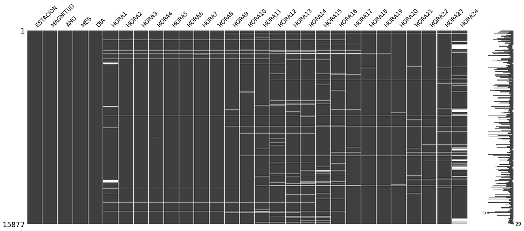

```python
import missingno as msno
msno.matrix(pm25)
```

### Derretir datos (wide to long)

El método `melt` de pandas se utiliza para "desenrollar" o "derretir" un DataFrame, transformando su estructura para que sea más larga y estrecha. Permite reorganizar los datos de manera que las columnas se convierten en variables y las filas se replican según esas variables. Este proceso es útil para trabajar con datos en un formato más adecuado para análisis y visualización.

Brevemente, el `melt` realiza las siguientes operaciones:

1. **Selecciona las Columnas de Identificación (`id_vars`):** Se especifican las columnas que se mantendrán sin cambios y actuarán como identificadores únicos para cada fila.
2. **Transforma las Columnas en Variables (`value_vars`):** Las columnas especificadas se "derriten" y se colocan en una nueva columna llamada "variable", donde cada valor representa una variable diferente.
3. **Crea una Columna de Valores (`value_name`):** Se crea una columna llamada "value" que contiene los valores correspondientes a las variables "derretidas".

Este proceso es particularmente útil cuando se trabaja con datos en formato ancho (muchas columnas) y se desea cambiar a un formato largo para facilitar ciertos tipos de análisis y visualizaciones.

```python
pm25m = pd.melt(pm25, id_vars=['ESTACION', 'MAGNITUD', 'ANO', 'MES', 'DIA'])
pm25m = pm25m.sort_values(['ESTACION', 'ANO', 'MES', 'DIA'])
pm25m.head()
```

|  | ESTACION | MAGNITUD | ANO | MES | DIA | variable | value |
| --- | --- | --- | --- | --- | --- | --- | --- |
| 6205 | BELISARIO | PM2.5 | 2008 | 1 | 1 | HORA1 | 48.68 |
| 22082 | BELISARIO | PM2.5 | 2008 | 1 | 1 | HORA2 | 97.01 |
| 37959 | BELISARIO | PM2.5 | 2008 | 1 | 1 | HORA3 | 93.51 |
| 53836 | BELISARIO | PM2.5 | 2008 | 1 | 1 | HORA4 | 61.88 |
| 69713 | BELISARIO | PM2.5 | 2008 | 1 | 1 | HORA5 | 41.20 |

- La estación `GUAMANI` apenas está presente, vamos a remover esta estación del dataframe.

```python
pm25m.ESTACION.value_counts()
```

```
ESTACION
BELISARIO      75384
CENTRO         75288
COTOCOLLAO     74952
CARAPUNGO      73968
EL CAMAL       58344
LOS CHILLOS    23088
GUAMANI           24
Name: count, dtype: int64
```

En pandas, el método `query` se utiliza para filtrar filas de un DataFrame según una expresión booleana específica. Proporciona una forma concisa y legible de seleccionar datos basándose en condiciones específicas.

- Ejemplo de uso de query en pandas

```
resultado = dataframe.query('condicion')
```

- Otra forma equivalente

```
resultado = dataframe[dataframe['condicion']]
```

```python
pm25m = pm25m.query("ESTACION != 'GUAMANI'")
```

### Viusalización de los datos

`seaborn.relplot` es una función en la biblioteca Seaborn de Python que se utiliza para crear gráficos de relaciones. Esta función es especialmente útil para visualizar la relación entre dos variables en un conjunto de datos. Puede representar datos en diferentes formatos, como dispersión (scatter plots) o líneas (line plots), y también facilita la creación de subgráficos basados en otras variables categóricas.

- `x` y `y` especifican las variables en el eje $x$ e $y$, respectivamente.
- `data` es el DataFrame que contiene los datos.
- `kind` determina el tipo de gráfico, en este caso, "scatter" para un gráfico de dispersión.
- `hue` y `style` permiten agregar información adicional mediante colores y estilos diferentes para subgrupos de datos.

Seaborn espera que la operación `melt` previamente descrita, haya sido realizada, para poder construir los gráficos a continuación.

- Vea: https://si2lab-udla.shinyapps.io/airquito/

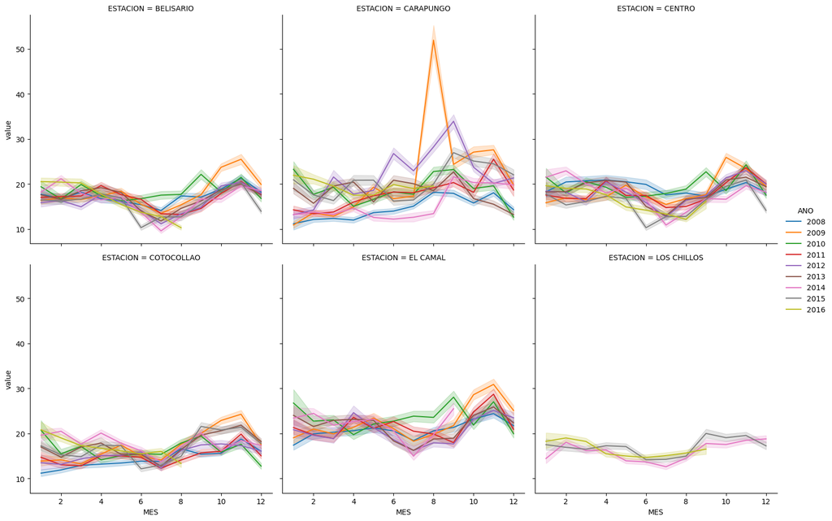

```python
import seaborn as sns
pm25m["ANO"] = pd.Categorical(pm25m.ANO)
sns.relplot(data=pm25m, x="MES", y="value",
    hue="ANO", col="ESTACION", col_wrap=3,
    kind='line')
```

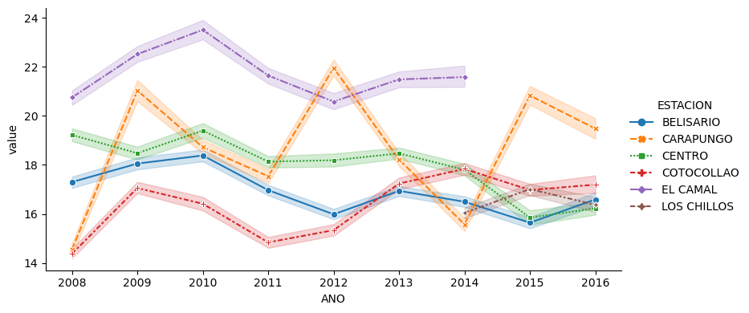

```python
sns.relplot(data=pm25m, x="ANO", y="value", hue="ESTACION", style="ESTACION",
            kind='line', markers=True, height=4, aspect=2
           )
```

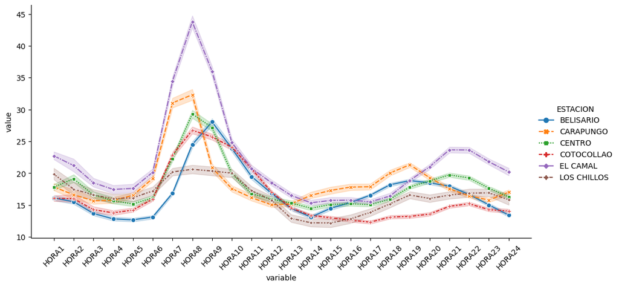

```python
sns.relplot(data=pm25m, x="variable", y="value", hue="ESTACION",
            style="ESTACION", kind='line', markers=True, height=5, aspect=2)
plt.xticks(rotation=45);
```

### Unión de variables

En pandas, las operaciones de cadena (string) se refieren a las funciones y métodos que se pueden aplicar a las columnas de tipo cadena en un DataFrame. Estas operaciones permiten realizar manipulaciones, transformaciones y análisis de datos basados en texto. A continuación, se describen algunas de las operaciones de cadena comunes en pandas:

- **Concatenación de Cadenas:** `str.cat()`: Concatena las cadenas de dos Series.
- **Extracción de Subcadenas:** `str.slice()`, `str[índice_inicio:índice_fin]`: Extraen porciones específicas de las cadenas.
- **Mayúsculas y Minúsculas:** `str.upper()`: Convierte a mayúsculas. `str.lower()`: Convierte a minúsculas. `str.capitalize()`: Convierte la primera letra a mayúscula.
- **Reemplazo y Eliminación:** `str.replace()`: Reemplaza parte de una cadena por otra. `str.strip()`: Elimina espacios en blanco al inicio y al final de la cadena.
- **Búsqueda y Conteo:** `str.contains()`: Verifica si una cadena contiene otra. `str.count()`: Cuenta las ocurrencias de una subcadena.
- **Longitud y Espacios:** `str.len()`: Calcula la longitud de cada cadena. `str.split()`: Divide una cadena en una lista de subcadenas.
- **Formato y Conversión:** `str.format()`: Formatea una cadena con valores específicos. `str.extract()`: Extrae patrones específicos utilizando expresiones regulares.

Vamos a utilizar estos métodos para unir las variables `['ANO', 'MES', 'DIA', 'HORA']` en una sola columna `DATE_TIME`.

```python
# Convertimos a string las columnas especificadas
pm25m[['ANO', 'MES', 'DIA']] = pm25m[['ANO', 'MES', 'DIA']].astype(str)
pm25m['MES'] = pm25m['MES'].str.rjust(2,'0')  # Agregamos padding de 0s
pm25m['DIA'] = pm25m['DIA'].str.rjust(2,'0')  # Agregamos padding de 0s

# Unimos DIA MES y ANO usando como separado /
pm25m['DATE'] = pm25m['DIA'].str.cat([pm25m['MES'], pm25m['ANO']], sep='/')

# Removemos HORA de la columna variable y agregamos padding de 0
# y sumamos minutos y segundos
pm25m['HORA'] = pm25m['variable'].str.replace('HORA', '')

# Hora va de 1 a 24, resto 1 para tener 0 a 23
# antes debo transformar el string a numérico para restar
# y vuelvo a trasnformar a string para concatenar mins y seg
pm25m['HORA'] =  (pd.to_numeric(pm25m['HORA'])-1).astype(str).str.rjust(2,'0') + ':00:00'

pm25m['DATE_TIME'] =  pm25m['DATE'].str.cat(pm25m['HORA'], sep=' ')

pm25m.head(3)
```

|  | ESTACION | MAGNITUD | ANO | MES | DIA | variable | value | DATE | HORA | DATE_TIME |
| --- | --- | --- | --- | --- | --- | --- | --- | --- | --- | --- |
| 6205 | BELISARIO | PM2.5 | 2008 | 01 | 01 | HORA1 | 48.68 | 01/01/2008 | 00:00:00 | 01/01/2008 00:00:00 |
| 22082 | BELISARIO | PM2.5 | 2008 | 01 | 01 | HORA2 | 97.01 | 01/01/2008 | 01:00:00 | 01/01/2008 01:00:00 |
| 37959 | BELISARIO | PM2.5 | 2008 | 01 | 01 | HORA3 | 93.51 | 01/01/2008 | 02:00:00 | 01/01/2008 02:00:00 |

```python
# Seleccionamos las columnas que nos interesan
datos_final = pm25m[['ESTACION', 'DATE_TIME', 'value']]

# Cambiamos nombres a las columnas
datos_final = datos_final.rename(columns={'ESTACION': 'Station',
                            'DATE_TIME': 'Date_time', 'value': 'pm25ugm3'})

# Guardar archivo csv
datos_final.to_csv('./data/03pm25ugm3.csv', index=False)

datos_final.head(3)
```

|  | Station | Date_time | pm25ugm3 |
| --- | --- | --- | --- |
| 6205 | BELISARIO | 01/01/2008 00:00:00 | 48.68 |
| 22082 | BELISARIO | 01/01/2008 01:00:00 | 97.01 |
| 37959 | BELISARIO | 01/01/2008 02:00:00 | 93.51 |

**Ejercicio autónomo**

### Unir dataframes

- Una vez procesados todos los archivos en excel procedemos a unir todos los `csv`.

```
# Establecer la ruta del directorio
path = "./data/csv_quito/"

# Crear una lista de archivos CSV en el directorio especificado
archivos = sorted(glob.glob(os.path.join(path, "0*.csv")))
```

Estas líneas de código en Python realizan las siguientes operaciones:

- `path = "./data/csv_quito/`: Establece la variable path con la ruta del directorio "./data/csv_quito/". Esta ruta se utiliza para especificar la ubicación de los archivos CSV que se van a procesar.
- `archivos = sorted(glob.glob(os.path.join(path, "0*.csv")))`: Utiliza la biblioteca glob y el módulo os para crear una lista de archivos CSV en el directorio especificado por path. Aquí está la descomposición:
- `os.path.join(path, "0*.csv")`: Combina la ruta del directorio con el patrón de búsqueda "0*.csv". Esto significa que se buscarán archivos que comiencen con "0" y tengan extensión ".csv" en el directorio especificado.
- `glob.glob(...)`: Utiliza el método glob para encontrar todos los archivos que coinciden con el patrón especificado. Devuelve una lista de nombres de archivos que cumplen con esa condición.
- `sorted(...)`: Ordena alfabéticamente los nombres de archivo en la lista. Esto es útil para asegurar un orden consistente al procesar varios archivos.

Estas líneas de código establecen una ruta de directorio y luego generan una lista de archivos CSV en ese directorio que cumplen con un patrón específico. La lista de archivos se almacena en la variable archivos, la cual estará ordenada alfabéticamente.

```python
# Vamos a listar los archivos csv en el directorio
# y guardar en una lista
import glob, os

# path a los datos csv
path = "./data/csv_quito/"
archivos = sorted(glob.glob(os.path.join(path, "0*.csv")))
archivos
```

```
['./data/csv_quito/00precipitation.mm.csv',
 './data/csv_quito/01wind_direction.deg.csv',
 './data/csv_quito/02wind_speed.ms.csv',
 './data/csv_quito/03pm25ugm3.csv']
```

**Leer los datos en una lista de `dataframes`**

```python
# Leemos todos los archivos csv creando una lista de dataframes (dfs)
dfs = [pd.read_csv(a) for a in archivos]

# Para obtener una sola estación filtre los datos
# Vamos a filtrar cada dataframe
# por la estacion BELISARIO usando loc
# Eliminamos la información de Station (estación)
#for i in range(len(dfs)):
#    dfs[i] = dfs[i].loc[dfs[i]['Station'] == 'BELISARIO']  # Filtro por estación
#    dfs[i] = dfs[i].drop('Station', 1)

dfs[1].head(3)  # dataframe 1: 01wind_direction.deg.csv
```

|  | Station | Date_time | wind_direction.deg |
| --- | --- | --- | --- |
| 0 | BELISARIO | 1/01/2008 00:00:00 | 87.96 |
| 1 | BELISARIO | 1/01/2008 01:00:00 | 72.26 |
| 2 | BELISARIO | 1/01/2008 02:00:00 | 86.11 |

### Merge dataframes

La función `merge` en pandas se utiliza para combinar dos DataFrames en función de una o más columnas comunes, similar a las operaciones de JOIN en SQL. Permite realizar operaciones de fusión horizontal, donde se unen las filas de dos DataFrames en función de valores coincidentes en una o más columnas. A continuación, se explican los parámetros clave y su uso:

```
result = pd.merge(left, right, how='inner', on=None, left_on=None,
                  right_on=None, left_index=False, right_index=False,
                  suffixes=('_left', '_right'), sort=False)
```

- `left` y `right`: Los DataFrames que se van a combinar. `how`: Especifica el tipo de fusión y puede ser **'inner'** (intersección), **'outer'** (unión), **'left'** (izquierda) o **'right'** (derecha).
- `on`: Columna o lista de columnas en las que se basará la fusión.
- `left_on` y `right_on`: Columnas del DataFrame izquierdo y derecho, respectivamente, para fusionar si las columnas de fusión tienen nombres diferentes.
- `left_index` y `right_index`: Si son **True**, utiliza los índices del DataFrame izquierdo o derecho, respectivamente, como las columnas de fusión.
- `suffixes`: Sufijos a agregar a los nombres de columnas en caso de conflicto.
- `sort`: Si es **True**, ordena el resultado según las columnas de fusión.

```python
d_final = dfs[0]  # Asignamos a d_final el dataframe 0
for d in dfs[1:]:  # Del dataframe 1 al final
    # Realizamos un merge usando la fecha y la estación como base para la fusión (on)
    d_final = d_final.merge(d, on=['Date_time', 'Station'], how='left')

d_final
```

|  | Station | Date_time | precipitation.mm | wind_direction.deg | wind_speed.ms | pm25ugm3 |
| --- | --- | --- | --- | --- | --- | --- |
| 0 | BELISARIO | 1/01/2008 00:00:00 | 0.0 | 87.96 | 1.57 | 48.68 |
| 1 | BELISARIO | 1/01/2008 01:00:00 | 0.0 | 72.26 | 1.53 | 97.01 |
| 2 | BELISARIO | 1/01/2008 02:00:00 | 0.0 | 86.11 | 2.22 | 93.51 |
| 3 | BELISARIO | 1/01/2008 03:00:00 | 0.0 | 76.69 | 1.85 | 61.88 |
| 4 | BELISARIO | 1/01/2008 04:00:00 | 0.0 | 107.54 | 1.23 | 41.20 |
| ... | ... | ... | ... | ... | ... | ... |
| 504427 | TUMBACO | 19/09/2016 19:00:00 | NaN | NaN | NaN | NaN |
| 504428 | TUMBACO | 19/09/2016 20:00:00 | NaN | NaN | NaN | NaN |
| 504429 | TUMBACO | 19/09/2016 21:00:00 | NaN | NaN | NaN | NaN |
| 504430 | TUMBACO | 19/09/2016 22:00:00 | NaN | NaN | NaN | NaN |
| 504431 | TUMBACO | 19/09/2016 23:00:00 | NaN | NaN | NaN | NaN |

504432 rows × 6 columns

```python
# Guardamos el resultado en un archivo csv
# no incluimos el índice primera columna en negrita arriba
d_final.to_csv("./data/merged_data_with_missing_values.csv", index=False)
```

### Eliminar todos los valores faltantes (no es la mejor idea)

La función `dropna` en pandas se utiliza para eliminar filas o columnas que contienen valores nulos (NaN). Puede aplicarse a un DataFrame completo o a una Serie específica y permite gestionar datos faltantes eliminando las observaciones que los contienen.

**Parámetros:**

- `axis`: Indica si se eliminarán filas (axis=0) o columnas (axis=1) que contengan valores nulos.
- `how`: Especifica la condición que debe cumplirse para que se elimine una fila o columna. Puede ser 'any' (si hay al menos un NaN) o 'all' (si todos los valores son NaN

```python
# Eliminamos registros en el eje 0 filas
# how=any, cualquier fila que tenga un nan es eliminada
d_final = d_final.dropna(axis=0, how='any')
d_final.to_csv("./data/merged_data_no_missing_values.csv", index=False)
d_final
```

|  | Station | Date_time | precipitation.mm | wind_direction.deg | wind_speed.ms | pm25ugm3 |
| --- | --- | --- | --- | --- | --- | --- |
| 0 | BELISARIO | 1/01/2008 00:00:00 | 0.0 | 87.96 | 1.57 | 48.68 |
| 1 | BELISARIO | 1/01/2008 01:00:00 | 0.0 | 72.26 | 1.53 | 97.01 |
| 2 | BELISARIO | 1/01/2008 02:00:00 | 0.0 | 86.11 | 2.22 | 93.51 |
| 3 | BELISARIO | 1/01/2008 03:00:00 | 0.0 | 76.69 | 1.85 | 61.88 |
| 4 | BELISARIO | 1/01/2008 04:00:00 | 0.0 | 107.54 | 1.23 | 41.20 |
| ... | ... | ... | ... | ... | ... | ... |
| 428430 | LOS CHILLOS | 12/09/2016 06:00:00 | 0.0 | 75.70 | 1.01 | 26.06 |
| 428431 | LOS CHILLOS | 12/09/2016 07:00:00 | 0.0 | 86.80 | 1.12 | 43.03 |
| 428432 | LOS CHILLOS | 12/09/2016 08:00:00 | 0.0 | 350.20 | 0.97 | 21.61 |
| 428433 | LOS CHILLOS | 12/09/2016 09:00:00 | 0.0 | 172.10 | 1.35 | 24.66 |
| 428434 | LOS CHILLOS | 12/09/2016 10:00:00 | 0.0 | 191.20 | 2.15 | 11.79 |

294983 rows × 6 columns

### Ingeniería de características y visualización de datos

- Una vez filtrado el dataset (`Station==Belisario`) y resumida la serie temporal, en un promedio diario sin fines de semana (`resample('D')`), tenemos el archivo que vamos a analizar a continuación.
- Vamos a construir características a partir de los variables `WINDDIR(deg)` y `WINDSPEED(m/s)` para representar tanto la dirección como la intensidad del viento en diferentes sectores.
- Este análisis no será temporal, la variable `DATE` se descartará.

```python
datos = pd.read_csv("./data/Belisario_missing_values.csv")
datos[:3]  # equivalente a head(3)
```

|  | DATE | PRECIPITATION(mm) | WINDDIR(deg) | WINDSPEED(m/s) | PARTICULAS(microg/m3) |
| --- | --- | --- | --- | --- | --- |
| 0 | 01/06/2007 | 9.3 | 125.09 | 1.91 | 24.84 |
| 1 | 04/06/2007 | 0.1 | 200.03 | 2.77 | 17.81 |
| 2 | 05/06/2007 | 0.0 | 178.09 | 3.24 | 15.86 |

```python
# No usaremos la fecha, es un promedio diario sin fines de semana
# Es decir haremos una exploración de datos no temporal
datos = datos[['PRECIPITATION(mm)', 'WINDDIR(deg)', 'WINDSPEED(m/s)', 'PARTICULAS(microg/m3)']]
datos.head()
```

|  | PRECIPITATION(mm) | WINDDIR(deg) | WINDSPEED(m/s) | PARTICULAS(microg/m3) |
| --- | --- | --- | --- | --- |
| 0 | 9.3 | 125.09 | 1.91 | 24.84 |
| 1 | 0.1 | 200.03 | 2.77 | 17.81 |
| 2 | 0.0 | 178.09 | 3.24 | 15.86 |
| 3 | 0.0 | 45.07 | 2.56 | 26.33 |
| 4 | 0.0 | 44.83 | 2.09 | 23.46 |

**isnull**

En pandas, el método para verificar si un valor es nulo es **`isnull()`**. Este método devuelve un DataFrame o una Serie de valores booleanos que indican si cada elemento en la estructura de datos es un valor nulo o no.

```python
# parte de los null originales fueron sumarizados en el resample('D')
datos.isnull().sum()  # contamos los nan en cada variable
```

```
PRECIPITATION(mm)         2
WINDDIR(deg)             27
WINDSPEED(m/s)           14
PARTICULAS(microg/m3)    40
dtype: int64
```

- Parte de los null originales fueron sumarizados en el `resample('D')`, y solo aquellos días que no tuvieron ninguna observación constan como nulos.

| Columna | Nulos |
| --- | --- |
| DATE | 0 |
| PRECIPITATION(mm) | 2 |
| WINDDIR(deg) | 27 |
| WINDSPEED(m/s) | 14 |
| PARTICULAS(microg/m3) | 40 |

- Muy pocos, por tanto optaremos por reemplazar por la media.

```python
datos.describe()
```

|  | PRECIPITATION(mm) | WINDDIR(deg) | WINDSPEED(m/s) | PARTICULAS(microg/m3) |
| --- | --- | --- | --- | --- |
| count | 1585.000000 | 1560.000000 | 1573.000000 | 1547.000000 |
| mean | 3.111483 | 115.795154 | 1.888563 | 18.421028 |
| std | 6.199882 | 60.975295 | 0.619789 | 5.528733 |
| min | 0.000000 | 0.020000 | 0.250000 | 5.740000 |
| 25% | 0.000000 | 71.767500 | 1.540000 | 14.745000 |
| 50% | 0.100000 | 116.285000 | 1.730000 | 18.190000 |
| 75% | 3.100000 | 154.662500 | 2.070000 | 21.870000 |
| max | 40.300000 | 359.400000 | 6.240000 | 57.110000 |

**Apply**

Las funciones lambda en pandas se utilizan comúnmente para aplicar operaciones rápidas y específicas a los datos de un DataFrame o una Serie. Estas funciones son funciones anónimas, lo que significa que no tienen un nombre definido. Se crean utilizando la palabra clave `lambda` y se pueden aplicar a través de métodos como `apply`, `map` o `applymap` en pandas.

En pandas, el método `apply` se utiliza para aplicar una función a lo largo de un eje de un DataFrame. Puede aplicarse a cada columna (eje 0) o a cada fila (eje 1).

```python
# Funciones lambda
# https://stackoverflow.com/questions/890128/why-are-python-lambdas-useful
# Vamos a reemplazar los valores faltantes por la media
# apply:
# axis 0 or ‘index’: apply function to each column
# axis 1 or ‘columns’: apply function to each row
datos = datos.apply(lambda x: x.fillna(x.mean()), axis=0)
datos.isnull().sum()
```

```
PRECIPITATION(mm)        0
WINDDIR(deg)             0
WINDSPEED(m/s)           0
PARTICULAS(microg/m3)    0
dtype: int64
```

```python
datos.describe()
```

|  | PRECIPITATION(mm) | WINDDIR(deg) | WINDSPEED(m/s) | PARTICULAS(microg/m3) |
| --- | --- | --- | --- | --- |
| count | 1587.000000 | 1587.000000 | 1587.000000 | 1587.000000 |
| mean | 3.111483 | 115.795154 | 1.888563 | 18.421028 |
| std | 6.195972 | 60.454046 | 0.617047 | 5.458568 |
| min | 0.000000 | 0.020000 | 0.250000 | 5.740000 |
| 25% | 0.000000 | 72.540000 | 1.540000 | 14.865000 |
| 50% | 0.100000 | 115.795154 | 1.740000 | 18.360000 |
| 75% | 3.111483 | 153.545000 | 2.065000 | 21.730000 |
| max | 40.300000 | 359.400000 | 6.240000 | 57.110000 |

### Ingeniería de características

- La ingeniería de características es un proceso en el que se crean nuevas variables (características) a partir de las existentes para mejorar el rendimiento de un modelo o facilitar su interpretación.
- En el contexto de la dirección y velocidad del viento, convertir las coordenadas polares a cartesianas es un ejemplo de ingeniería de características que puede hacer que los datos sean más accesibles para algunos algoritmos de aprendizaje automático.
- En meteorología, la dirección del viento y la velocidad del viento a menudo se representan en coordenadas polares, donde la dirección es el ángulo y la velocidad es la distancia desde el origen. Convertir estas coordenadas polares a cartesianas (coordenada X, Y) puede simplificar el manejo de la información y permitir que ciertos algoritmos aprovechen mejor los datos.
- La variable a modelar es continua (PM2.5: `PARTICULAS(microg/m3))`, por lo tanto estamos frente a un problema de regresión.
  - Podemos expresar esta variable de forma categórica usando umbralización a partir de valores dados por expertos.
  - Ej.: La OMS, la regulación del municipio, entre otros.
  - En este caso estaríamos frente a un problema de clasificación.
- Esta discritización será realizada usando `np.where` para crear las columnas `PL2` y `PL3` para un problema de clasificación binaria (clases H: Healthy, UH: Unhealthy) y multiclase (3 clases: L: Low, M: Medium, H: High contamination).
  - En pandas, `np.where` se utiliza para realizar operaciones basadas en condiciones y asignar valores en función de esas condiciones. `np.where` es parte de la biblioteca NumPy, y se utiliza para realizar evaluaciones booleanas en un array NumPy y devolver valores basados en esas evaluaciones.

```python
# Polar to Cartesian
datos['X'] = np.cos(datos['WINDDIR(deg)']*np.pi/180)*datos['WINDSPEED(m/s)']  # wind speed is the radius
datos['Y'] = np.sin(datos['WINDDIR(deg)']*np.pi/180)*datos['WINDSPEED(m/s)']
# WHO says that over 15 is bad (the expert).
datos['PL2'] = np.where(datos['PARTICULAS(microg/m3)']>=15, 'UH', 'H')
datos['PL3'] = np.where(datos['PARTICULAS(microg/m3)']<10, 'L',
                        np.where(datos['PARTICULAS(microg/m3)']<25, 'M', 'H'))
datos.head(10)
```

|  | PRECIPITATION(mm) | WINDDIR(deg) | WINDSPEED(m/s) | PARTICULAS(microg/m3) | X | Y | PL2 | PL3 |
| --- | --- | --- | --- | --- | --- | --- | --- | --- |
| 0 | 9.3 | 125.09 | 1.91 | 24.84 | -1.097987 | 1.562858 | UH | M |
| 1 | 0.1 | 200.03 | 2.77 | 17.81 | -2.602452 | -0.948759 | UH | M |
| 2 | 0.0 | 178.09 | 3.24 | 15.86 | -3.238200 | 0.107988 | UH | M |
| 3 | 0.0 | 45.07 | 2.56 | 26.33 | 1.807980 | 1.812404 | UH | H |
| 4 | 0.0 | 44.83 | 2.09 | 23.46 | 1.482232 | 1.473462 | UH | M |
| 5 | 0.1 | 85.26 | 2.37 | 21.83 | 0.195843 | 2.361894 | UH | M |
| 6 | 0.0 | 66.72 | 2.53 | 14.72 | 0.999919 | 2.324019 | H | M |
| 7 | 0.0 | 39.28 | 2.40 | 16.98 | 1.857747 | 1.519466 | UH | M |
| 8 | 0.6 | 13.12 | 2.43 | 14.31 | 2.366569 | 0.551589 | H | M |
| 9 | 0.8 | 126.14 | 2.25 | 17.20 | -1.326961 | 1.817051 | UH | M |

```python
# Guardamos ciertas columnas en dependencia del analisis
# que se realizará eventualmente
# Problema de regresión
datos_regresion = datos[['X', 'Y', 'PRECIPITATION(mm)', 'PARTICULAS(microg/m3)']]
# Problema de clasificación binaria
datos_binclass = datos[['X', 'Y', 'PRECIPITATION(mm)', 'PL2']]
# Problema multiclase
datos_mulclass = datos[['X', 'Y', 'PRECIPITATION(mm)', 'PL3']]
datos_regresion.to_csv("regressionData_pandas.csv", index=False)
datos_binclass.to_csv("binClassData_pandas.csv", index=False)
datos_mulclass.to_csv("mulClassData_pandas.csv", index=False)
```

**Visualización (pandas)**

Un scatterplot (gráfico de dispersión) con `hue` es una representación gráfica que utiliza puntos para visualizar la relación entre dos variables, y utiliza un tercer atributo (`hue`) para colorear los puntos según un valor específico. Esta técnica es especialmente útil cuando deseas explorar la relación entre dos variables mientras también consideras la contribución de una tercera variable categórica o continua.

- Variables `x` e `y`: Representan las variables que se comparan en los ejes horizontal y vertical.
- `hue`: Especifica la variable continua que se utiliza para asignar colores a los puntos.
- Mapa de colores (cmap): Determina la paleta de colores utilizada para representar los valores continuos.
- Barra de color (colorbar): Proporciona una referencia visual de cómo se asignan los colores a los valores continuos.
- Si la variable hue es categórica el gráfico colorea los puntos según la categoría. Cada categoría se representa con un color diferente en el gráfico.

**Para todas las visualizaciones siguientes usaremos `pandas.plot`**

- `pandas.plot` es un método de visualización incorporado en pandas que facilita la creación de gráficos directamente desde un DataFrame o una Serie de pandas. Este método se basa en la biblioteca de visualización de Python llamada Matplotlib, y proporciona una interfaz más sencilla y conveniente para crear gráficos sin tener que llamar directamente a funciones de Matplotlib.

La sintaxis básica de `pandas.plot` es la siguiente:

```
DataFrame.plot(x=None, y=None, kind='line', ax=None, subplots=False, layout=None, title=None, grid=None, legend=True, style=None, logx=False, logy=False, loglog=False, xticks=None, yticks=None, xlim=None, ylim=None, rot=None, fontsize=None, colormap=None, table=False, yerr=None, xerr=None, secondary_y=False, sort_columns=False, **kwds)
```

- `x` y `y`: Son etiquetas de columna o índices que se utilizan como datos para los ejes x e y respectivamente.
- `kind`: Tipo de gráfico (por defecto, 'line' para gráficos de líneas).
- `ax`: Un objeto de ejes de Matplotlib en el que se debe realizar el gráfico.
- `subplots`: Si es True, crea un gráfico por cada columna.
- `title`: Título del gráfico.
- `grid`: Si es True, muestra las líneas de la cuadrícula.
- `legend`: Si es True, muestra la leyenda.
- `style`: Estilo de línea y marcadores.
- `xticks` y `yticks`: Posiciones de las marcas en los ejes x e y.
- `xlim` y `ylim`: Límites de los ejes x e y.
- `fontsize`: Tamaño de la fuente.
- `colormap`: Colormap para tramas de líneas.
- `table`: Si es True, agrega una tabla con los valores.

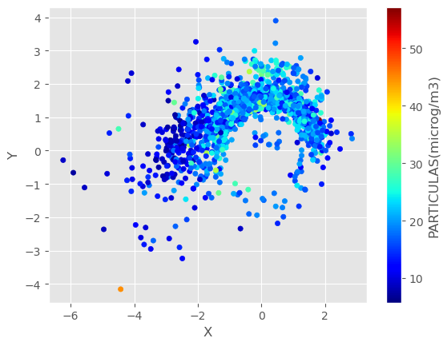

```python
# Visualización de datos usando Pandas
# Para colormap ver:
# https://matplotlib.org/examples/color/colormaps_reference.html
import matplotlib
matplotlib.style.use('ggplot')
from matplotlib import cm

datos_regresion.plot.scatter('X', 'Y', c='PARTICULAS(microg/m3)', colormap=cm.jet)
plt.show()
```

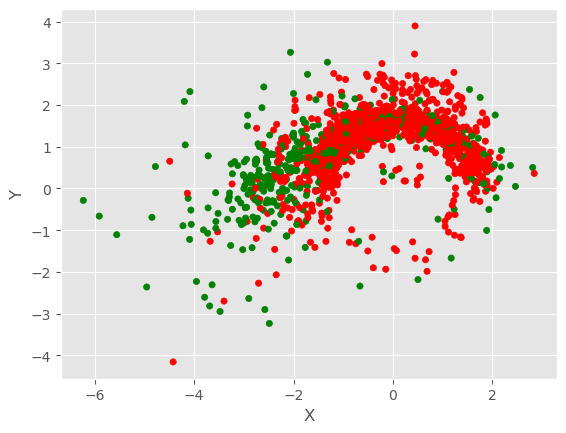

```python
datos_bin = pd.read_csv("binClassData_pandas.csv")
# Asignamos un color a cada clase para representar en el scatterplot
colclass = {'H':'green', 'UH':'red'}
colores = datos_bin['PL2'].apply(lambda x: colclass[x])
datos_bin.plot.scatter('X', 'Y', c=colores)
plt.show()
```

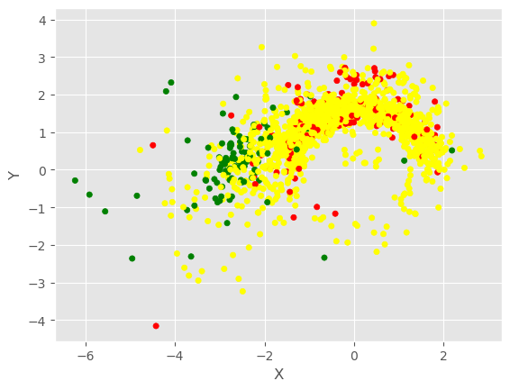

```python
datos_mul = pd.read_csv("mulClassData_pandas.csv")
# Asignamos un color a cada clase para representar en el scatterplot
colors = {'H':'red', 'M': 'yellow', 'L':'green'}
colores = datos_mul['PL3'].apply(lambda x: colors[x])
datos_mul.plot.scatter('X', 'Y', c=colores)
plt.show()
```

**Un density plot (gráfico de densidad)** es una representación visual de la distribución de un conjunto de datos continuos. A diferencia de un histograma, que divide los datos en intervalos y cuenta la frecuencia en cada intervalo, un density plot suaviza la distribución subyacente mediante la estimación de la densidad de probabilidad.

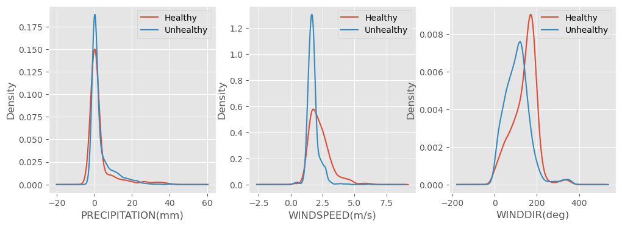

```python
plt.figure(figsize=(12,4))
plt.subplot(1,3,1)
datos['PRECIPITATION(mm)'].groupby(datos['PL2']).plot(kind='kde')
plt.legend(("Healthy", "Unhealthy"))
plt.xlabel('PRECIPITATION(mm)')

plt.subplot(1,3,2)
datos['WINDSPEED(m/s)'].groupby(datos['PL2']).plot(kind='kde')
plt.legend(("Healthy", "Unhealthy"))
plt.xlabel('WINDSPEED(m/s)')

plt.subplot(1,3,3)
datos['WINDDIR(deg)'].groupby(datos['PL2']).plot(kind='kde')
plt.legend(("Healthy", "Unhealthy"))
plt.xlabel('WINDDIR(deg)');
```

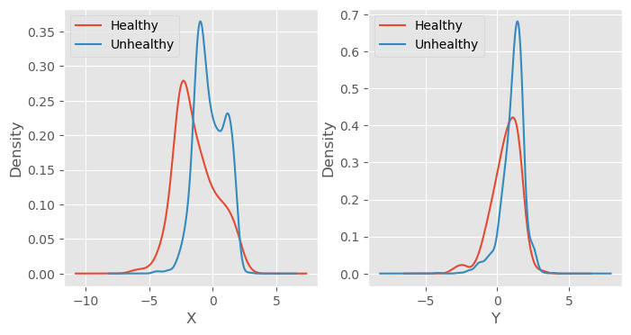

```python
plt.figure(figsize=(8,4))
plt.subplot(1,2,1)
datos['X'].groupby(datos['PL2']).plot(kind='kde')
plt.legend(("Healthy", "Unhealthy"))
plt.xlabel('X')

plt.subplot(1,2,2)
datos['Y'].groupby(datos['PL2']).plot(kind='kde')
plt.legend(("Healthy", "Unhealthy"))
plt.xlabel('Y');
```

**Un histograma** es una representación gráfica de la distribución de un conjunto de datos. Se utiliza para visualizar la frecuencia con la que ocurren diferentes valores en un conjunto de datos continuo y proporciona una forma rápida de entender la forma y la dispersión de la distribución.

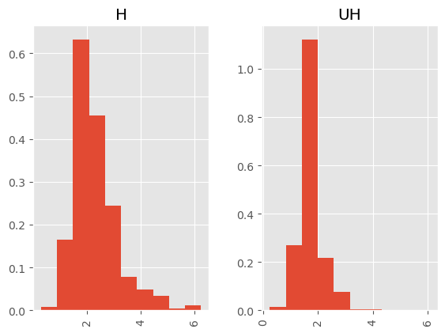

```python
datos['WINDSPEED(m/s)'].hist(by=datos['PL2'], density=True)
plt.show()
```

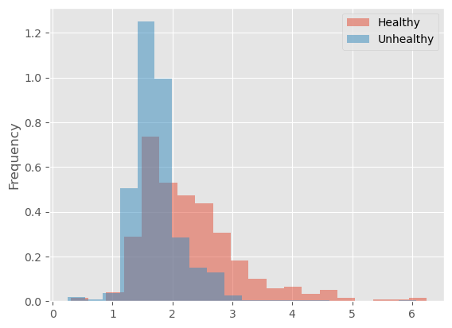

```python
datos['WINDSPEED(m/s)'].groupby(datos['PL2']).plot(kind='hist', density=1, bins=20, stacked=True, alpha=.5)
plt.legend(("Healthy", "Unhealthy"))
plt.show()
```

**Visualización de series temporales**

- Lectura de archivo con una columna de tipo de datos que se usará como índice temporal
  - **`./data/merged_data_no_missing_values.csv`**: Este es el camino relativo o absoluto al archivo CSV que estás leyendo. Asegúrate de que el archivo existe en esa ubicación.
  - **`index_col=[1]`**: Esto establece que la segunda columna del archivo CSV (índice 1 en base cero) se utilizará como el índice del DataFrame. Es decir, los valores en esa columna se usarán como etiquetas de fila en el DataFrame.
  - **`parse_dates=[1]`**: Este argumento indica a pandas que debe intentar interpretar las fechas en la segunda columna del archivo CSV como objetos de fecha y hora. En este caso, se está especificando que la columna en la posición 1 (nuevamente, en base cero) contiene fechas que deben ser interpretadas como objetos de fecha y hora.
  - **`dayfirst=True`**: Este argumento se utiliza en conjunto con parse_dates. Indica a pandas que, si las fechas tienen el formato día-mes-año, debe interpretarlas de esa manera. Es decir, si tienes una fecha como "01-02-2023", pandas la interpretará como el 1 de febrero de 2023.

  Finalmente, el DataFrame resultante se almacena en la variable llamada data. Este DataFrame contendrá los datos del archivo CSV, y la segunda columna se utilizará como índice, y si hay fechas en esa columna, se interpretarán como objetos de fecha y hora.

```python
data = pd.read_csv("./data/merged_data_no_missing_values.csv",
                        index_col=[1], parse_dates=[1], dayfirst=True)
data.head()
```

| Date_time | Station | precipitation.mm | wind_direction.deg | wind_speed.ms | pm25ugm3 |
| --- | --- | --- | --- | --- | --- |
| 2008-01-01 00:00:00 | BELISARIO | 0.0 | 87.96 | 1.57 | 48.68 |
| 2008-01-01 01:00:00 | BELISARIO | 0.0 | 72.26 | 1.53 | 97.01 |
| 2008-01-01 02:00:00 | BELISARIO | 0.0 | 86.11 | 2.22 | 93.51 |
| 2008-01-01 03:00:00 | BELISARIO | 0.0 | 76.69 | 1.85 | 61.88 |
| 2008-01-01 04:00:00 | BELISARIO | 0.0 | 107.54 | 1.23 | 41.20 |

```python
data.tail()
```

| Date_time | Station | precipitation.mm | wind_direction.deg | wind_speed.ms | pm25ugm3 |
| --- | --- | --- | --- | --- | --- |
| 2016-09-12 06:00:00 | LOS CHILLOS | 0.0 | 75.7 | 1.01 | 26.06 |
| 2016-09-12 07:00:00 | LOS CHILLOS | 0.0 | 86.8 | 1.12 | 43.03 |
| 2016-09-12 08:00:00 | LOS CHILLOS | 0.0 | 350.2 | 0.97 | 21.61 |
| 2016-09-12 09:00:00 | LOS CHILLOS | 0.0 | 172.1 | 1.35 | 24.66 |
| 2016-09-12 10:00:00 | LOS CHILLOS | 0.0 | 191.2 | 2.15 | 11.79 |

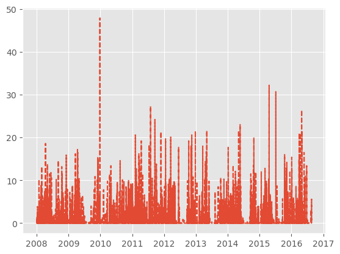

```python
# filtrado de datos solo estación belisario
belisario = data.query("Station=='BELISARIO'")
plt.plot(belisario.index, belisario['precipitation.mm'], '--')
plt.show()
```

La expresión `resample('M').sum()` se utiliza en pandas para realizar una operación de remuestreo temporal sobre un DataFrame con fechas y luego calcular la suma para cada mes ('M' significa mensual).

- **`resample('M')`**: Este método se utiliza para cambiar la frecuencia temporal de los datos. En este caso, 'M' indica que queremos remuestrear a una frecuencia mensual. Si los datos tienen fechas diarias, este método agrupará los datos en meses.
- **`.sum()`**: Después de aplicar el remuestreo, .sum() se utiliza para calcular la suma de los valores en cada mes. Esto es especialmente útil si los datos representan cantidades acumulativas diarias y deseas obtener la suma mensual.

Creamos un dataframe solo para la variable **`precipitation.mm`** que puede ser usado para un análisis univariado de series temporales.

```python
# Creamos un dataframe solo para la variable precipitation.mm
m_summary = pd.DataFrame()
m_summary['precipitation.mm'] = belisario['precipitation.mm'].resample('M').sum()
m_summary.head()
```

| Date_time | precipitation.mm |
| --- | --- |
| 2008-01-31 | 122.8 |
| 2008-02-29 | 243.1 |
| 2008-03-31 | 140.6 |
| 2008-04-30 | 223.4 |
| 2008-05-31 | 200.2 |

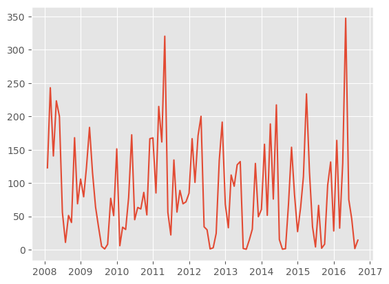

```python
# Gráfico de la serie sumarizada de forma mensual
plt.plot(m_summary.index, m_summary['precipitation.mm'], '-')
plt.show()
```

### Pivoting (formato long a wide)

La línea de código

```
data_w = data.pivot(index='Date_time', columns='Station')
```

se utiliza para realizar una operación de pivote en un DataFrame de pandas.

- Esta operación transforma el DataFrame original de una forma en la que las observaciones, que originalmente podrían estar en filas, se distribuyen en columnas, utilizando los valores de una columna específica como etiquetas de columna.
- El desglose de esta línea de código es:
  - `data:` Es el DataFrame original que contiene los datos.
  - `.pivot()`: Este método realiza la operación de pivote en el DataFrame.
  - `index='Date_time'`: Indica que la columna 'Date_time' se utilizará como el índice del nuevo DataFrame pivote.
  - `columns='Station'`: Indica que los valores únicos de la columna 'Station' se utilizarán como etiquetas de columna en el nuevo DataFrame pivote.
- **Note** que el resultado es un dataframe con doble indexación de columnas en nuestro caso particular.

```python
# Leemos de nuevo el dataset, esta vez sin indexar por fecha para realizar el pivote
data = pd.read_csv("./data/merged_data_no_missing_values.csv", parse_dates=[1])
data_w = data.pivot(index='Date_time', columns='Station')
data_w.head()
```

| Station Date_time | precipitation.mm BELISARIO | precipitation.mm CARAPUNGO | precipitation.mm COTOCOLLAO | precipitation.mm EL CAMAL | precipitation.mm LOS CHILLOS | wind_direction.deg BELISARIO | wind_direction.deg CARAPUNGO | wind_direction.deg COTOCOLLAO | wind_direction.deg EL CAMAL | wind_direction.deg LOS CHILLOS | wind_speed.ms BELISARIO | wind_speed.ms CARAPUNGO | wind_speed.ms COTOCOLLAO | wind_speed.ms EL CAMAL | wind_speed.ms LOS CHILLOS | pm25ugm3 BELISARIO | pm25ugm3 CARAPUNGO | pm25ugm3 COTOCOLLAO | pm25ugm3 EL CAMAL | pm25ugm3 LOS CHILLOS |
| --- | --- | --- | --- | --- | --- | --- | --- | --- | --- | --- | --- | --- | --- | --- | --- | --- | --- | --- | --- | --- |
| 1/01/2008 00:00:00 | 0.0 | 0.0 | 0.0 | 0.0 | NaN | 87.96 | 296.03 | 22.47 | 27.13 | NaN | 1.57 | 1.03 | 0.91 | 1.57 | NaN | 48.68 | 104.85 | 82.94 | 118.28 | NaN |
| 1/01/2008 01:00:00 | 0.0 | 0.0 | 0.0 | 0.0 | NaN | 72.26 | 333.93 | 26.15 | 95.80 | NaN | 1.53 | 1.43 | 1.34 | 1.19 | NaN | 97.01 | 163.40 | 165.31 | 257.67 | NaN |
| 1/01/2008 02:00:00 | 0.0 | 0.0 | 0.0 | 0.0 | NaN | 86.11 | 305.11 | 5.62 | 86.02 | NaN | 2.22 | 1.05 | 0.84 | 1.20 | NaN | 93.51 | 47.07 | 59.23 | 215.42 | NaN |
| 1/01/2008 03:00:00 | 0.0 | 0.0 | 0.0 | 0.0 | NaN | 76.69 | 298.29 | 39.49 | 27.95 | NaN | 1.85 | 0.88 | 0.71 | 1.42 | NaN | 61.88 | 12.38 | 43.73 | 82.81 | NaN |
| 1/01/2008 04:00:00 | 0.0 | 0.0 | 0.0 | 0.0 | NaN | 107.54 | 288.13 | 5.33 | 60.53 | NaN | 1.23 | 0.95 | 0.78 | 0.93 | NaN | 41.20 | 7.81 | 35.25 | 46.68 | NaN |

### Comparar estaciones

- Este formato nos va a ser útil para comparar las diferentes variables en las diferentes estaciones.
- A continuación vamos a hacer un muestreo diario de los datos.

```python
# copiamos el dataset
df = data_w.copy()
# creamos un índice a partir de la fecha
df = df.set_index(pd.DatetimeIndex(df.index))
```

```python
df_D = df.resample('D').mean()  # resample data daily (mean)

# for precipitation use a cumulative value (sum)
df_D['precipitation.mm'] = df['precipitation.mm'].resample('D').sum()

df_D.tail()
```

| Station Date_time | precipitation.mm BELISARIO | precipitation.mm CARAPUNGO | precipitation.mm COTOCOLLAO | precipitation.mm EL CAMAL | precipitation.mm LOS CHILLOS | wind_direction.deg BELISARIO | wind_direction.deg CARAPUNGO | wind_direction.deg COTOCOLLAO | wind_direction.deg EL CAMAL | wind_direction.deg LOS CHILLOS | wind_speed.ms BELISARIO | wind_speed.ms CARAPUNGO | wind_speed.ms COTOCOLLAO | wind_speed.ms EL CAMAL | wind_speed.ms LOS CHILLOS | pm25ugm3 BELISARIO | pm25ugm3 CARAPUNGO | pm25ugm3 COTOCOLLAO | pm25ugm3 EL CAMAL | pm25ugm3 LOS CHILLOS |
| --- | --- | --- | --- | --- | --- | --- | --- | --- | --- | --- | --- | --- | --- | --- | --- | --- | --- | --- | --- | --- |
| 2016-12-05 | 0.0 | 0.1 | 0.0 | 0.0 | 0.1 | 221.500000 | 178.641667 | 165.620833 | NaN | 139.800000 | 1.578750 | 1.727917 | 1.764167 | NaN | 1.822083 | 16.117917 | 18.806667 | 15.392917 | NaN | 16.401667 |
| 2016-12-06 | 0.0 | 0.0 | 0.0 | 0.0 | 0.0 | 144.412500 | 236.079167 | 122.541667 | NaN | 203.233333 | 1.705417 | 1.615000 | 1.975000 | NaN | 2.147917 | 8.944167 | 10.657917 | 9.024583 | NaN | 12.029167 |
| 2016-12-07 | 0.0 | 0.0 | 0.0 | 0.0 | 0.0 | 204.529167 | 262.412500 | 141.920833 | NaN | 188.234783 | 1.649583 | 1.963333 | 1.813750 | NaN | 2.010870 | 13.177500 | 15.714167 | 14.342500 | NaN | 15.304783 |
| 2016-12-08 | 3.1 | 0.0 | 0.0 | 0.0 | 0.0 | 190.241667 | 262.270833 | NaN | NaN | 144.179167 | 1.728750 | 1.759583 | NaN | NaN | 1.810417 | 11.248750 | 18.102917 | NaN | NaN | 13.980000 |
| 2016-12-09 | 0.0 | 0.0 | 0.0 | 0.0 | 0.0 | NaN | NaN | NaN | NaN | 159.527273 | NaN | NaN | NaN | NaN | 1.140000 | NaN | NaN | NaN | NaN | 18.775455 |

### Valores faltantes

- Propogna qué hacer para tratar los valores faltantes

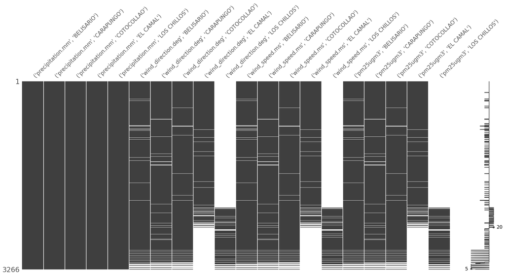

```python
msno.matrix(df_D)
```

### Visualización (plotly)

Plotly es una biblioteca de visualización interactiva para Python que permite la creación de gráficos interactivos y dashboards.

- Comparamos visualmente las variables comparando estaciones.
  - Podemos seleccionar la variable y el nivel de muestreo: Month, Quarter, Year.

[figure not shown]

  - Scale: escalado min-max de los datos entre 0 y 1.

La técnica `min-max` se utiliza para normalizar datos, ajustándolos a un rango específico, comúnmente entre 0 y 1. La fórmula de transformación es:

$$ X_{\text{escalado}} = \frac{X - X_{\text{min}}}{X_{\text{max}} - X_{\text{min}}} $$

Donde:

- $X$ es el valor original.
- $X_{\text{min}}$ es el valor mínimo en el conjunto de datos.
- $X_{\text{max}}$ es el valor máximo en el conjunto de datos.

```python
import ipywidgets
import plotly.express as px
from sklearn.preprocessing import MinMaxScaler

@ipywidgets.interact
def plot(var=data.columns[2:],
         resample=['M', 'Q', 'Y'],
         scale=False,
        ):
    df_V = df_D[var]  # seleccionamos una sola de las variables
    df_r = df_V.copy()
    # Muestreo acumulado para preciptation.mm
    if var == "precipitation.mm":
        df_r = df_r.resample(resample).sum()
    # En caso contrario una media (para dirección de viento quizás no sea un buen indicador)
    else:
        df_r = df_r.resample(resample).mean()
    if scale:
        scaler = MinMaxScaler()  # definir escalado
        scaler = scaler.fit(df_r)  # esclar datos
        df_r = pd.DataFrame(scaler.transform(df_r), columns=df_r.columns, index=df_r.index)
    fig = px.line(df_r, x=df_r.index, y=df_r.columns, title=var)
    fig.show()
```

```
interactive(children=(Dropdown(description='var', options=('precipitation.mm', 'wind_direction.deg', 'wind_spe…
```